# Tutorial Outline

1. Getting ready
2. Downloading reads from SRA
3. Raw read quality
4. Adapter removal
5. Low quality trimming and filtering
6. Processed read quality
7. There's more...

# 1. Getting ready

Raw sequence reads are typically stored in fastq file format (https://en.wikipedia.org/wiki/FASTQ_format). Before we can begin our analysis of the sequence data, we have to process the raw reads. Why? Well, raw reads often contain adapter sequences that were added in the library preparation that will not match the source genome(s) for the reads. Additionally, the quality (confidence in the base call) can be low overall for a read or low at the 3' end where errors are more likely. To deal with these issues we can run computer programs that edit reads or filter out low quality reads. Instead of blindly running these programs and assuming all is well with our reads, we typically run a quality control analysis before and after read processing to see if the read processing succeeded and to catch any additional issues with our reads that may not be dealt with by the read processing we did.

# 2. Downloading reads from SRA

Before we dig into read processing, we will first learn how to download fastq files for specific accession IDs in the SRA database.

For this lab tutorial we have selected a microbial RNAseq dataset: https://trace.ncbi.nlm.nih.gov/Traces/sra/?study=SRP001753

This dataset is unusually small, making it a nice example to get started on so that you are not stuck waiting for lengthy downloads or read processing steps. Keep in mind that these steps will take longer for most datasets.

We will download the four fastq files in the dataset using a bash script that we already wrote for you. Let's look at it.

```python
%%bash

cat fastq_dump.sh
```

The **`fastq-dump`** command is from the Sequence Read Archive Toolkit (http://ncbi.github.io/sra-tools/) that we have already installed on the server and put into your path. If you wanted to use the toolkit on a different computer, you would need to install it.

**`fastq-dump`** takes an accession number (e.g. SRR034450). Every entry in the SRA database has its own accession number. **`fastq-dump`** downloads the fastq file associated with that accession number to the directory that it is run in.

We added **`echo`** and **`date`** commands to the bash script so that we could follow the progress of the downloads. In this case the files are relatively small and the downloading should happen quickly (~10min) so this information isn't particularly important. However, if you were working with really big files (as you will later in the course), knowing how the download is going and how long it is taking would very helpful.

You can run **`fastq_dump.sh`** in this notebook, however the output won't be printed to the screen until after it completes. If you want to see the output as the script is running, then run the following command (not including the `%%bash`) in the terminal.

```python
%%bash

bash fastq_dump.sh
```

Let's have a look at the first ten lines of each of the files we just downloaded.

```python
%%bash

head *.fastq
```

What did you learn looking at the first ten lines of the four fastq files?

# 3. Raw read quality

Before we begin processing the fastq files, it is good to run a quality control analysis to have a baseline for the quality of the raw reads.

We have installed a program called **`fastqc`** (https://anaconda.org/bioconda/fastqc) on the server that runs a standard quality control analysis on a fastq file and outputs an .html report file that can be viewed in a web browswer.

We have written a script that will run **`fastqc`** on all of the fastq files in the current directory. Let's have a look at it.

```python
%%bash

cat fastqc_dir.sh
```

Do you understand what the bash script is doing?

OK, let's run the bash script. Again, you can run it here in the notebook and not see the output until it is done running or you can run it in the terminal and see the output while it is running.

```python
%%bash

bash fastqc_dir.sh
```

Now let's open up one of the .html output files in from the Jupyter file browser page that you logged in on.

A table at the top of the file gives you some basic stats.

Next are a series of many different graphs and tables.

### Per base sequence quality

Here is an example of the first graph, the per base sequence quality:

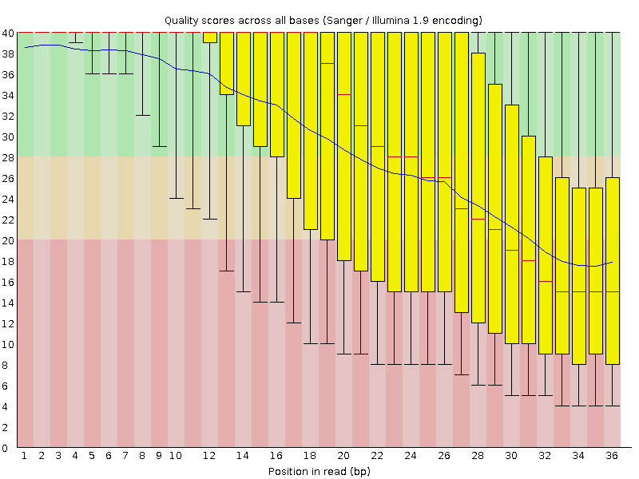

The y-axis is the quality score and the x-axis is the position in the read (basepairs 1-36). There is both a boxplot (yellow boxes with a red median) and a mean trace (blue). The quality scores in this graph and elsewhere in the analysis are what are called Phred quality scores. A Phred quality score of 32 means the sequencing machine estimated the probability of getting the base wrong as $10^{-3.2}$. So higher scores correspond with lower probabilities of errors. An quality score of 20 or above (less than 1 in 100 chance of error) is generally considered acceptable and below 20 is generally considered unacceptable.

### Per tile sequence quality

The next plot is the per tile sequence quality. This is showing you how sequence quality relates to the physical location of reads on the flow cell. It should not be highly spacially structured. If it is then something might have done wrong with how the sequencing machine was run. If a sequencing facility did your sequencing it is possible they would redo it if the overall quality is low and it is highly spacially structured.

### Per sequence quality scores

The next plot is a histogram of the per read average quality score.

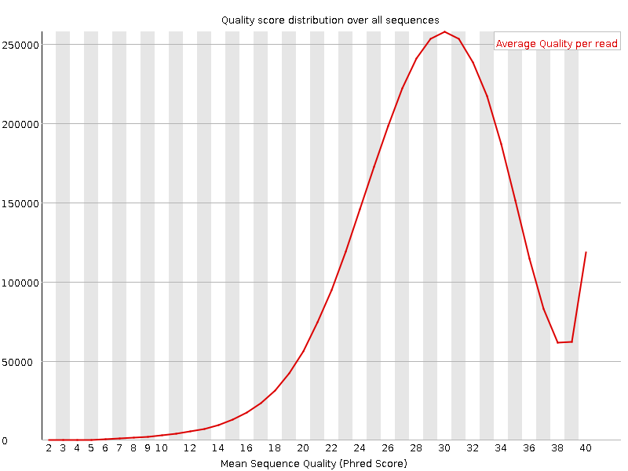

In the graph above, the mode is 30, which isn't great. The long left tail of the distribution indicates there are many low quality reads.

### Per base sequence content

The next graph shows the percentage nucleotide composition on the y-axis and position in read on the x-axis. The percentages should be consistent across positions. Many organisms have have an uneven GC vs AT content which could be reflected in graph.

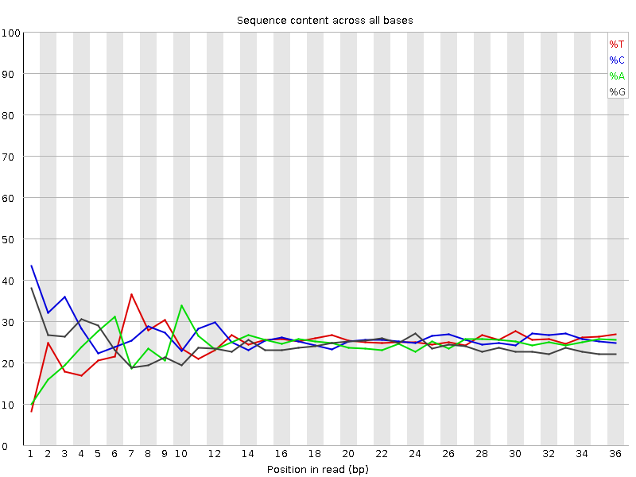

In this example the GC content is high relative to AT for the first ~5-10bp but then levels off. This kind of skew is very common in fragmented and randomly primed libraries, which this is an example. See this discussion for more information: https://sequencing.qcfail.com/articles/positional-sequence-bias-in-random-primed-libraries/

### Per sequence GC content

The next graph is a histogram of the percentage GC of the reads. It should look normally distributed.

### Per base N content

Reads near the edges of a flow cell can be difficult to image and make base calls for. This can result in insufficient information to make a base call and the sequencing machine may put an 'N' in place of a nucleotide in the read sequence, where 'N' represents any possible nucleotides [ATCG]. This next graph shows the percentage of reads with an N at each position. This should be very close to zero.

### Sequence length distribution

The next graph shows the histogram of sequence lengths.

### Sequence duplication levels

There are numerous reasons why duplicate reads may appear in a dataset. The main reasons that can be of some concern are if the sample was contaminated or if PCR amplification steps in the library preparation had a biased outcome where some reads were highly replicated while others were not. However the design of the experiment can produce duplication that is not of concern. For example, very deep sequencing (high coverage) or high representation of specific sequences (say a highly expressed gene in an RNAseq experiment) can naturally result in duplication that is fine.

The next graph plots percentage of reads vs level of duplication (replication) as a blue line. The reads used for the graph are just the first 100,000 sequences in the fastq file (but it checks the whole file to see if those 100,000 reads are duplicated). The red line on the graph is not particularly intuitive. It takes those 100,000 reads, imagines the fastq file without any duplicates, and asks what percentage of the new file do these reads make up. It then plots the reads with the same x-axis value as they had for the blue line, but now with updated percentages based on a shrunk de-deduplicated fastq file.

The goal of looking at this graph is to determine if it looks like you have a concerning level of duplication. Unfortunately, it isn't really enough information for you to distinguish OK cases of duplication from problematic ones. What the graph can do is tell you if there is a lot of duplication (unique sequences are <80% of total) and then you can look further to see if this seems to be the result of good or bad duplication.

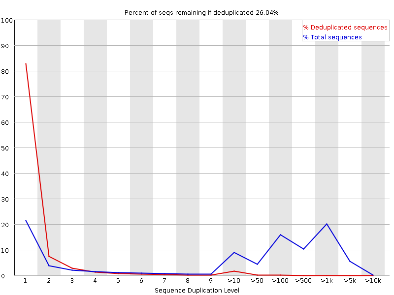

In this example, there is definitely a lot of duplication and very high levels of duplication as well. This is an RNAseq experiment so it could be the result of highly expressed genes but it also could be something bad. **`fastqc`** returned a failed test for sequence duplication levels, suggesting these are not ordinary levels of duplication. It is certainly worth looking into further.

### Overrepresented sequences

Another way to look at duplication of reads is to list all of the most duplicated sequences and attempt to figure out if they are common contaminants in sequencing experiments. **`fastqc`** reports all reads that make up more than 0.1% of the fastq file. For each it searches a database of sequences that are common contaminants and either reports the match or reports that no hit was found.

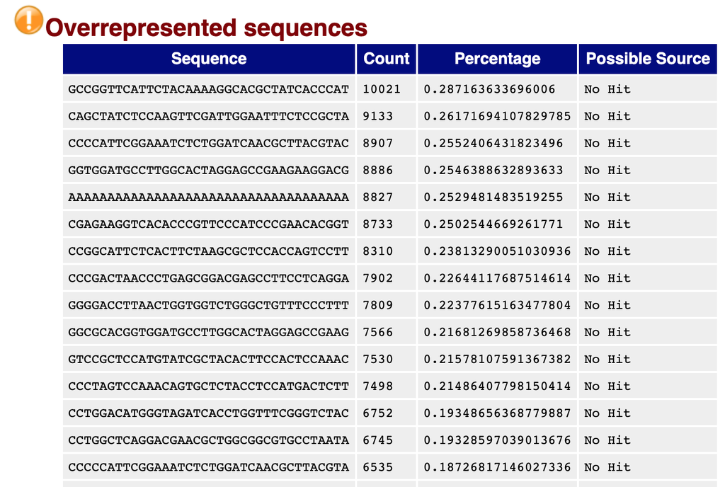

In this example, 60 overrepresented sequences were found. The top of the table is shown above. None of the overrepresented sequences matched the database of known contaminants. It is always worth taking some of the overrepresented reads in this table and Blasting them (https://blast.ncbi.nlm.nih.gov/Blast.cgi) to make sure they map to the species you are studying. In this case, the most overrepresented sequence is a 100% match to the Listeria monocytogenes genome. So this doesn't rule out PCR bias but the duplication may just be from highly expressed genes.

### Adapter content

When the DNA being sequenced is shorter than the length of the read, the read can continue into the adaptor on the 3' end of the read. **`fastqc`** searches for common adaptors and then reports this next graph showing the percentage of reads containing a match to an adaptor at each position in the read. It is very standard to run an adaptor removal step in read processing.

### Look over all of your fastqc files

Look through all of your fastqc files to get a sense for the baseline issues that may or may not be delt with in the read processing.

# 4. Adapter removal

As we learned at the end of the **`fastqc`** analysis, adapter sequences can show up at the 3' end of reads. Typically a program is run to remove commonly used adapter sequences from the 3' end of reads.

We have installed onto the server an adapter removal program celeverly called **`scythe`** (https://github.com/vsbuffalo/scythe). **`scythe`** needs to be given a fasta file containing the adapters used in the construction of the sequencing library.

According to the paper that our dataset came from (https://bmcgenomics.biomedcentral.com/articles/10.1186/1471-2164-10-641), they used the "Illumina Genomic DNA Sample Prep kit". The paper is ten years old so it took some digging to figure out what the adapters are for this kit that is not sold anymore. This document on Illumina's website had the adapter sequences: https://support.illumina.com/content/dam/illumina-support/documents/documentation/chemistry_documentation/experiment-design/illumina-adapter-sequences-1000000002694-10.pdf. We created a fasta file containing the two sequences. Let's look at them.

```python
%%bash

cat adapters.fa
```

Let's look at the usage for **`scythe`**.

```python
%%bash

scythe --help
```

We have written a bash script called **`scythe_dir.sh`**. Let's have a look at it.

```python
%%bash

cat scythe_dir.sh
```

Let's run the script to see what it does.

```python
%%bash

bash scythe_dir.sh
```

[output not shown]

Why did the script print out the usage statement? How did it know that no arguments were passed to it? The script needs an output directory. How does the script combine the output directory that gets passed to it with the fastq file names to generate a path to the output file?

**`scythe`** is going to create new fastq files that are adapter trimmed and we want to distinguish these from the raw fastq files. A nice way to do this is to output them to their own directory. Do you remember how to create a new directory? Make a new directory for the adapter trimmed fastq files.

```python
%%bash

# code to make a new directory goes here
```

Run the **`scythe_dir.sh`** script either in the notebook or in the terminal.

```python
%%bash

# code to run the script goes here (can run here or in the terminal)
```

Did scythe find any adapter sequences in the raw fastq files? What were the contamination rates? Were they consistent across samples?

# 5. Low quality trimming and filtering

As we learned above, low quality base calls are more likely at the 3' end of reads and some reads can generally have low quality. Depending on the goals of your sequencing experiment and how you plan to analyze your reads, errors in base calls may or may not be a big deal. Errors often mean you can't align a read to the reference genome and would end up tossing out reads with errors. Typically we'd like to save reads that just have low quality base calls at the ends so that we can use the information in the high quality part of the read. However, if the high quality part of the read is small or non-existant then we want to remove the read from our dataset because it won't be useful for us anyway.

Programs like **`sickle`** (https://github.com/najoshi/sickle) perform the task of trimming off low quality bases from the ends and filtering out reads. It works by scanning over each read using a window length of ~10% of the read length, starts the window at the 5' end and moves it one base at a time across the read to the 3' end, and at each position calculates the average quality in the window. When the average quality goes above a threshold (default is 20) then bases start getting added to the output read. When the average quality drops below the threshold then the program stops adding bases to the output read. If the output read has a length greater than or equal to a theshold (default is 20bp) then it is returned, otherwise the read is filtered out and nothing is returned for this read.

Let's look at the arguments **`sickle`** takes.

```python
%%bash

# the se is for single end reads. it can also be run with pe for paired end reads.
sickle se --help
```

There are lots of options. We will run it with the default arguments but it is not unusual to change these settings. Counterintuitively, we will use 'sanger' quality type because that is the type of quality scoring that Illumina has used for a long time.

Now we need a script to run **`sickle`**. Let's write one. You could either copy and edit (in **`nano`**) the **`scythe_dir.sh`** script or you could go straight to writing the script in **`nano`**. It will need to take your adapter trimmed fastq directory as an input argument. You will also need to make a new directory to output the trimmed fastq files and you'll want your script to take this output directory as an argument as well. Remember that **`nano`** needs to be run from the terminal.

Even if you don't run your script from the notebook, for record keeping, you might find it helpful to enter the command you run here.

```python
%%bash

# code you used to run your script here
```

Did sickle filter out a lot of reads? Was the proportion of filtered reads similar across samples?

# 6. Processed read quality

Now we want to rerun fastqc but this time on our processed reads. We can change our current working directory to be the directory containing the quality trimmed fastq files and then rerun the **`fastqc_dir.sh`** script to generate fastqc reports for each processed fastq file. When you have the fastqc files, compare them to the fastqc files for the raw fastq files. What has changed? Are there still any concerns? Do you need to redo any of the read processing?

```python
%%bash

# code you used to run your script here
```

## 7. There's more...

In this exercise, we were using the processing programs scythe/sickle but there are many other tools that have been developed to do these tasks. Below are some citations to review papers on read processing.

- Del Fabbro C, Scalabrin S, Morgante M, Giorgi FM (2013) An Extensive Evaluation of Read Trimming Effects on Illumina NGS Data Analysis. PLoS ONE 8(12): e85024. https://doi.org/10.1371/journal.pone.0085024
- Chen C, Khaleel SS, Huang H, Wu CH (2014) Software for pre-processing Illumina next-generation sequencing short read sequences. Source Code Biol Med 9:8. https://doi.org/10.1186/1751-0473-9-8